# Statistical analysis of precapillary sphincter data

Author

Teddy Groves

This analysis aims to model measurements of vessel diameter, pressure and pulsatility in the brain blood vessels of mice that were subjected to an experimental protocol designed to elicit vascular stress responses. The results will be used to assess differences in these responses between old and adult mice, between mice in general and between different types of brain blood vessels.

# Whisker stimulation data

In order to measure how the vascular responsiveness changed during our experimental protocol, the diameters of different vessel types was recorded before and during whisker stimulation, at baseline, post-hypertension and post-ablation stages. The ratio of the peak compared with the pre-stimulation level for each mouse at each stage, on natural logarithmic scale, also known as the ‘log change’, was standardised by subtracting the overall mean and dividing by the standard deviation, then treated as a single measurement.

This way of the measurements was chosen to facilitate modelling, as log change is a symmetric and additive measure of relative change (see Tornqvist, Vartia, and Vartia (1985)). Note that when the difference between the two values $v1$ and $v2$ is far less than 1, the log change $\ln{\frac{v2}{v1}}$is approximately the same as the classical relative difference $\frac{v2-v1}{v1}$.

We were interested in two specific questions pertaining to whisker stimulation:

1a) Is there a difference between old and adult mice in the diameter log change for different vessels?

1b) Does sphincter ablation affect diameter log change to a different extent for adult and old mice?

To answer these questions, we fit a Bayesian multilevel regression model.

## Missing data

We assume that all missing measurements were caused by factors that were unrelated to our main target process (equivalently that the absent measurements were “missing at random”). We therefore did not attempt to model the measurement removal process explicitly.

## Implementation

We implemented our model in Stan (Carpenter et al. 2017) and interfaced with data via the Python library cmdstanpy (Stan Development Team 2022). Posterior analysis was facilitated by the library arviz (Kumar et al. 2019). The analysis was orchestrated using the template package bibat (Groves 2023).

All the code implementing the analysis, as well as instructions for reproduction, can be found at https://github/teddygroves/sphincter.

## Statistical Model

The final model is shown below:

$$\begin{align}
y_{vtm} &\sim ST(\nu, \hat{y}_{vtm}, \sigma) \label{eq-whisker-model} \\
\hat{y}_{vtm} &= \mu
+ \alpha^{treatment}_{t}
+ \alpha^{vessel}_v
+ \alpha^{protocol}_{vt}
+ \beta^{age}_{vt} \cdot old(m)
+ \alpha^{mouse}_{vtm} \nonumber \\
\alpha^{treatment}_t &\sim N(0, \tau^{treatment}) \nonumber \\
\alpha^{vessel}_v &\sim N(0, \tau^{vessel}) \nonumber \\
\alpha^{protocol}_{vt} &\sim N(0, \tau^{protocol}) \nonumber \\
\alpha^{mouse}_{vtm} &\sim N(0, \tau^{mouse}_{t}) \nonumber \\
\beta^{age}_{vt} &\sim N(0, \tau^{age}) \nonumber \\
\nu &\sim Gamma(2, 0.1) \nonumber \\
\sigma &\sim HN(0, 0.5) \nonumber \\
\mu &\sim N(0, 0.7) \nonumber \\
\tau^{treatment} &\sim HN(0, 0.7) \nonumber \\
\tau^{vessel} &\sim HN(0, 0.7) \nonumber \\
\tau^{protocol} &\sim HN(0, 0.7) \nonumber
\end{align}$$

In equation $\eqref{eq-whisker-model}$, the term $ST$ indicates the student t distribution, $old$ is an indicator function with value $old(m)=1$ if mouse $m$ is old, and zero otherwise, $N$ indicates the normal distribution, $Gamma$ the gamma distribution and $HN$ the ‘half-normal’ distribution, i.e. the normal distribution with support only for non-negative numbers.

This model was the end result of fitting a series of Bayesian multilevel models, following the strategy outlined in Gelman et al. (2020). The prior standard deviation 0.7 was chosen because it led to what we judged to be a reasonable allocation of prior probability mass over possible data realisations. The prior for the student t degrees of freedom parameter $\nu$ was set following the recommendation in Juárez and Steel (2010).

This model is flexible enough to allow age effects that vary depending on treatment and vessel type, but also allows these parameters to be shrunk towards zero if the data suggests that there is little difference between these categories. Our questions can be answered by inspecting the parameters $\beta^{age}$. If, for a particular vessel type, our model allocates low probability mass to small values of this parameter, this indicates a difference between old and adult mice with respect to this vessel type. In particular, if the values for the sphincter vessel type tend to be far from zero, that would show an age difference for this vessel type.

## Results

Figure 1 shows the observed log change measurements with colours illustrating the various categorical information. Note that there is more variation in the baseline log change values than in the values after either treatment.

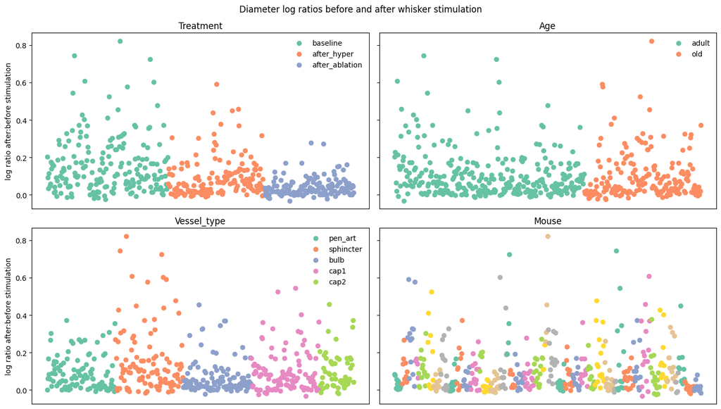

Figure 1: Raw measurements

Figure 2 compares the measurements with our model’s posterior predictive distribution. This shows that our model achieved a reasonable fit to the observed data. There is a pattern in the model’s bad predictions, in that these tend to be for higher baseline measurements. However, we judged that this pattern was small enough that for our purposes we could disregard it.

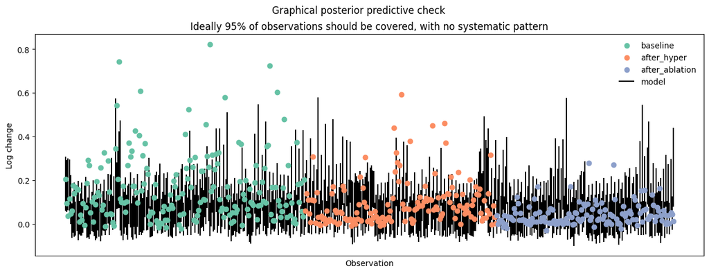

Figure 2: Graphical posterior predictive check

Figure 3 answers our questions 1a) and 1b): we found no significant age effects for any vessel or treatment.

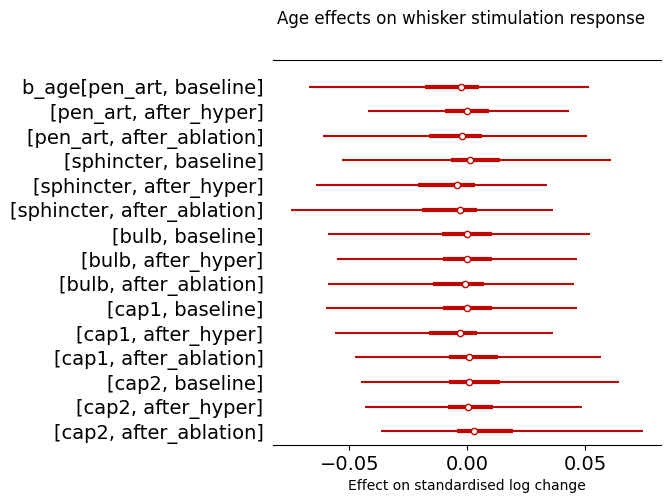

Figure 3: Marginal 2.5%-97.5% posterior intervals for age effects

This does not mean that there were no significant treatment effects, but just that these effects did not depend on age or vessel type. Figure 4 shows the marginal posterior distributions for hypertension and ablation effects relative to the baseline, showing a clear effect in both cases.

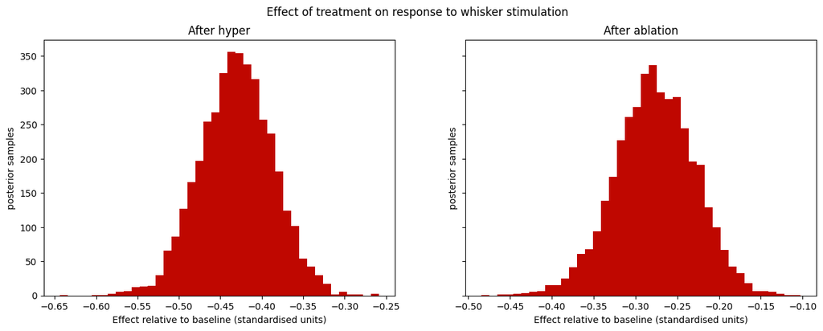

Figure 4: Marginal posterior intervals for treatment effects, relative to the baseline treatment.

These effects were the same for all vessel types, as can be seen from Figure 5, which shows that these were largely irrelevant.

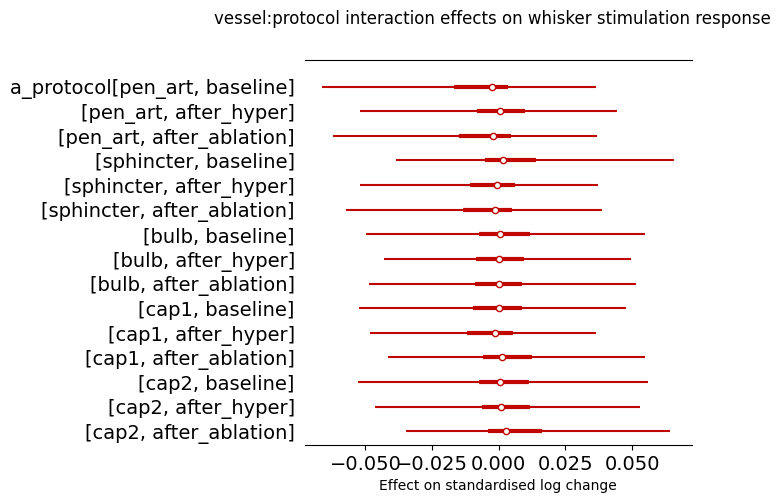

Figure 5: Marginal 2.5%-97.5% posterior intervals for protocol effects

There was also a significant distributional effect of treatment. This is captured by Figure 6, which shows marginal posterior distributions for the parameters $\tau^{mouse}$. It was higher for the baseline treatment than for either of the interventions, reflecting the pattern noted above in the raw data.

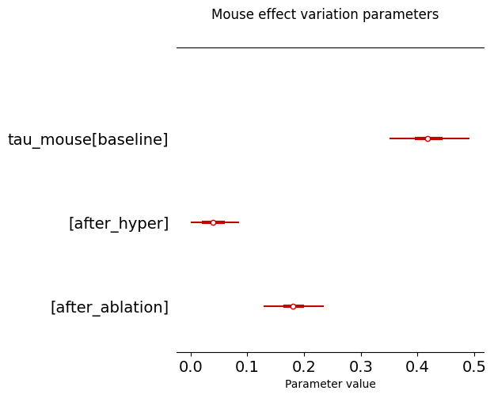

Figure 6: Marginal 2.5%-97.5% posterior intervals for $\tau^{mouse}$ parameters.

# Pulsatility data

## Missing data

Again we assumed that all absent measurements were missing at random.

## Statistical model

$$\begin{equation}
f(x, \lambda_1, \lambda_2) = \frac{\lambda_1\cdot\lambda_2}{\lambda_1-lambda_2}(\exp^{-x\lambda_2}-\exp^{-x\lambda_1})
\end{equation}$$

## Notes and Comments

- [] Statistical testing in general: in normal case we would do multiple hypothesis testing correction. Explain why it is OK to have a separate model for each question (because we assume the modelled processes are independent)
- [] Add an explanatory section at the start.
- [] Change parameter names to be more explicit about interaction terms

## References

Carpenter, Bob, Andrew Gelman, Matthew D. Hoffman, Daniel Lee, Ben Goodrich, Michael Betancourt, Marcus Brubaker, Jiqiang Guo, Peter Li, and Allen Riddell. 2017. “Stan: A Probabilistic Programming Language.” *Journal of Statistical Software* 76 (1): 1–32. https://doi.org/10.18637/jss.v076.i01.

Gelman, Andrew, Aki Vehtari, Daniel Simpson, Charles C. Margossian, Bob Carpenter, Yuling Yao, Lauren Kennedy, Jonah Gabry, Paul-Christian Bürkner, and Martin Modrák. 2020. “Bayesian Workflow.” *arXiv:2011.01808 [Stat]*, November. https://arxiv.org/abs/2011.01808.

Groves, Teddy. 2023. “Bibat: Batteries-Included Bayesian Analysis Template.” https://doi.org/10.5281/zenodo.7775328.

Juárez, Miguel A., and Mark F. J. Steel. 2010. “Model-Based Clustering of Non-Gaussian Panel Data Based on Skew-t Distributions.” *Journal of Business & Economic Statistics* 28 (1): 52–66. https://doi.org/10.1198/jbes.2009.07145.

Kumar, Ravin, Colin Carroll, Ari Hartikainen, and Osvaldo Martin. 2019. “ArviZ a Unified Library for Exploratory Analysis of Bayesian Models in Python.” *Journal of Open Source Software* 4 (33): 1143. https://doi.org/10.21105/joss.01143.

Stan Development Team. 2022. “CmdStanPy.” https://github.com/stan-dev/cmdstanpy.

Tornqvist, Leo, Pentti Vartia, and Yrjo O. Vartia. 1985. “How Should Relative Changes Be Measured?” *The American Statistician* 39 (1): 43–46. https://doi.org/10.2307/2683905.